# Prob 5, CP 1: Regressão e romance

## Dados

Temos dados descrevendo 5000 encontros relâmpagos envolvendo 310 jovens americanos. Os dados originais foram coletados por professores da Columbia Business School. Os participantes tinham vários encontros de 4 minutos por noite. Após cada um, preenchiam fichas avaliando aqueles com quem se encontraram. Cada linha nos dados representa um desses encontros. As informações na ficha representavam dados pessoais como idade e gênero, e opiniões do participante sobre a pessoa com quem ele se encontrou, além de avaliações sobre um possível relacionamento entre eles. Para a análise vamos utilizar os dados like (O quanto p1 gostou de p2), fun (Quão divertido p1 achou p2), attr (Quão atraente p1 achou p2) e amb (Quão ambicioso p1 achou p2), todas na escala de 0 a 10. Algumas linhas precisam ser filtradas para eliminar dados N/A, que ocorrem quando um participante não preencheu devidamente essa informação na ficha.

### Pergunta

Utilizando esses dados, vamos criar modelos de regressão para responder à seguinte pergunta: **uma pessoa divertida (fun) e atraente (attr) recebe maiores notas de like?**

Para visualizar melhor, vamos plotar as variáveis fun e attr em função de like.

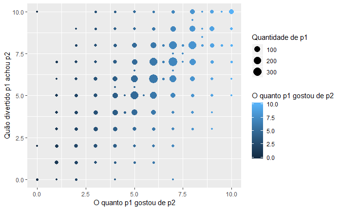

```r
dados %>%
    ggplot(aes(x = like, y = fun, color = like)) +
    geom_count() +
    labs(x = "O quanto p1 gostou de p2", y = "Quão divertido p1 achou p2", color = "O quanto p1 gostou de p2", size = "Quantidade de p1")
```

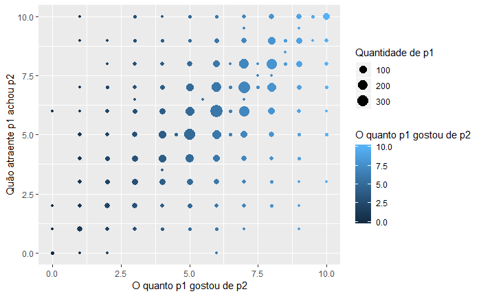

```r
dados %>%
    ggplot(aes(x = like, y = attr, color = like)) +
    geom_count() +
    labs(x = "O quanto p1 gostou de p2", y = "Quão atraente p1 achou p2", color = "O quanto p1 gostou de p2", size = "Quantidade de p1")
```

Em ambos os gráficos é possível visualizar uma certa relação entre as variáveis.

## Modelo

### amb

Para termos uma ideia do comportamento de um modelo de regressão, vamos utilizar a variável amb.

```r
modelo1 = lm(like ~ amb,
               data = dados)
kable(tidy(modelo1))
```

```
|term        |  estimate| std.error| statistic| p.value|
|:-----------|---------:|---------:|---------:|-------:|
|(Intercept) | 3.1927488| 0.0953396|  33.48818|       0|
|amb         | 0.4226171| 0.0137427|  30.75215|       0|
```

```r
kable(glance(modelo1))
```

```
|      | r.squared| adj.r.squared|    sigma| statistic| p.value| df|    logLik|      AIC|     BIC| deviance| df.residual|
|:-----|---------:|-------------:|--------:|---------:|-------:|--:|---------:|--------:|-------:|--------:|-----------:|
|value | 0.1750737|     0.1748886| 1.678695|  945.6948|       0|  2| -8633.945| 17273.89| 17293.1| 12557.08|        4456|
```

Esse modelo possui um R² muito baixo, portanto esse modelo explica apenas 17% da variabilidade da variável like.

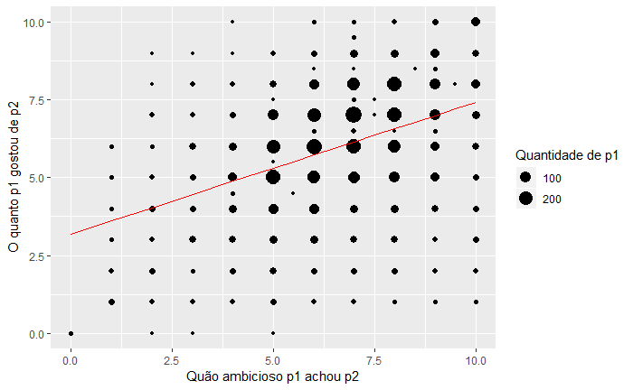

```r
dados %>%
    add_predictions(model = modelo1) %>%
    ggplot(aes(x = amb, y = like)) +
    geom_count() +
    geom_line(aes(y = pred), colour = "red") +
    labs(x = "Quão ambicioso p1 achou p2", y = "O quanto p1 gostou de p2", size = "Quantidade de p1") +
    NULL
```

### fun + attr

```r
modelo = lm(like ~ fun + attr,
               data = dados)
kable(tidy(modelo))
```

```
|term        |  estimate| std.error| statistic| p.value|
|:-----------|---------:|---------:|---------:|-------:|
|(Intercept) | 1.0535336| 0.0662292|  15.90738|       0|
|fun         | 0.4151519| 0.0110692|  37.50498|       0|
|attr        | 0.3911547| 0.0113034|  34.60503|       0|
```

```r
kable(glance(modelo))
```

```
|      | r.squared| adj.r.squared|    sigma| statistic| p.value| df|    logLik|      AIC|      BIC| deviance| df.residual|
|:-----|---------:|-------------:|--------:|---------:|-------:|--:|---------:|--------:|--------:|--------:|-----------:|
|value |  0.576903|      0.576713| 1.202355|   3037.25|       0|  3| -7145.659| 14299.32| 14324.93| 6440.409|        4455|
```

Com um R² mais elevado, podemos dizer que o modelo com essas variáveis explica 57% da variabilidade da variável like.

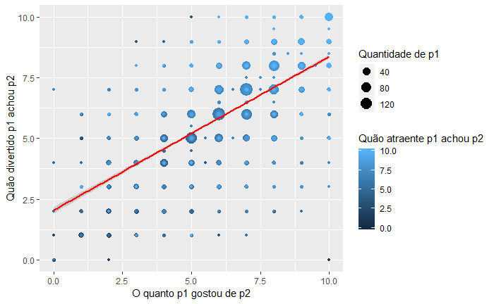

```r
dados %>%
    add_predictions(model = modelo) %>%
    ggplot(aes(x = fun, y = like, color = attr)) +
    geom_count() +
    geom_smooth(method = lm, color = "red") +
    labs(x = "O quanto p1 gostou de p2", y = "Quão divertido p1 achou p2", color = "Quão atraente p1 achou p2", size = "Quantidade de p1") +
    NULL
```

Portanto, respondendo à nossa pergunta, temos que o fato da pessoa ser atraente e divertida aumenta a nota que ela recebe no like.